# FEMALE REPRESENTATION IN POLITICS

```r
model2.1<- lm(data2004_clean$Score ~ data2004_clean$Liabilities)
model2.1
model2.2<- lm(data2009_clean$Score ~ data2009_clean$Liabilities)
model2.2
model2.3<- lm(data2014_clean$Score ~ data2014_clean$Liabilities)
model2.3
model2.4<- lm(data2019_clean$Score ~ data2019_clean$Liabilities)
model2.4
```

```
Call:
lm(formula = data2004_clean$Score ~ data2004_clean$Liabilities)

Coefficients:
               (Intercept)  data2004_clean$Liabilities
                 4.997e+01                  -5.064e-10
```

```
Call:
lm(formula = data2009_clean$Score ~ data2009_clean$Liabilities)

Coefficients:
               (Intercept)  data2009_clean$Liabilities
                 4.937e+01                  -2.491e-08
```

```
Call:
lm(formula = data2014_clean$Score ~ data2014_clean$Liabilities)

Coefficients:
               (Intercept)  data2014_clean$Liabilities
                 4.950e+01                   5.696e-08
```

```
Call:
lm(formula = data2019_clean$Score ~ data2019_clean$Liabilities)

Coefficients:
               (Intercept)  data2019_clean$Liabilities
                 5.081e+01                  -6.581e-09
```

Our objective here was to compare the number of criminal cases associated with female candidates pariticipating in the election.

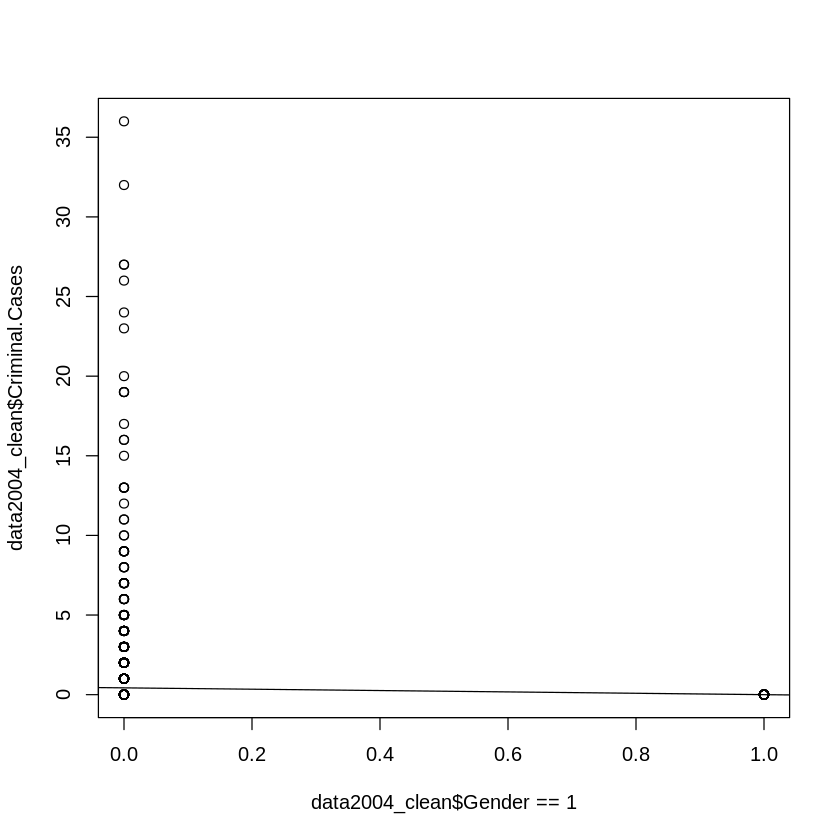

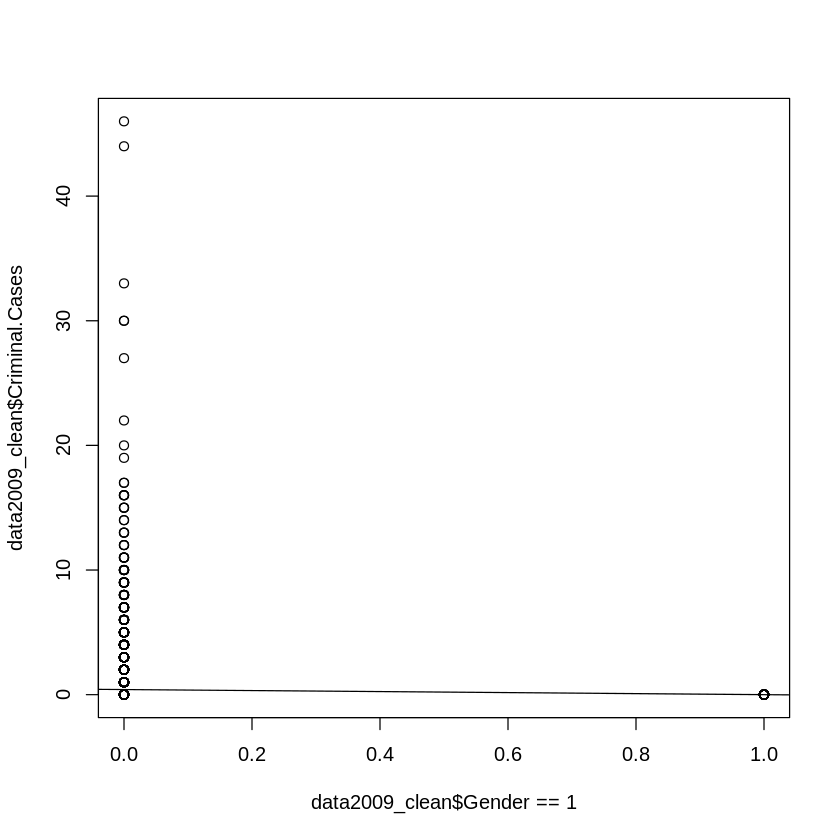

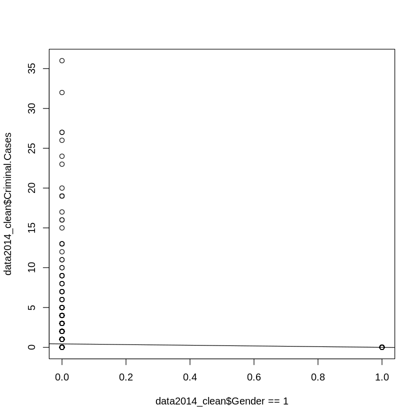

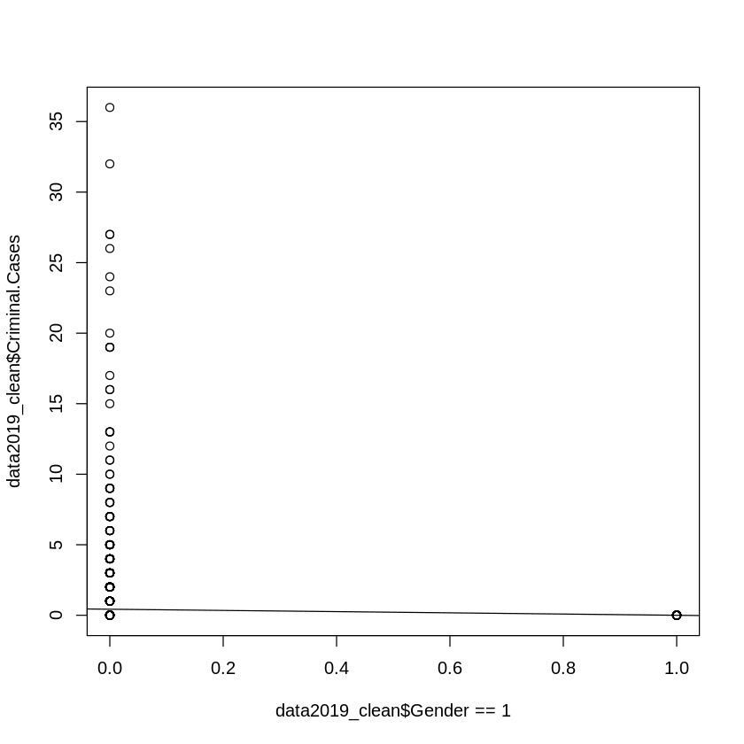

```r
plot(data2004_clean$Criminal.Cases ~ data2004_clean$Gender==1 )
abline(lm(data2004_clean$Criminal.Cases~ data2004_clean$Gender==1))
plot(data2009_clean$Criminal.Cases ~ data2009_clean$Gender==1 )
abline(lm(data2009_clean$Criminal.Cases~ data2009_clean$Gender==1))
plot(data2014_clean$Criminal.Cases ~ data2014_clean$Gender==1 )
abline(lm(data2014_clean$Criminal.Cases~ data2014_clean$Gender))
plot(data2019_clean$Criminal.Cases ~ data2019_clean$Gender==1)
abline(lm(data2019_clean$Criminal.Cases~ data2019_clean$Gender==1))
```

```r
model3.1<- lm(data2004_clean$Criminal.Cases ~ data2004_clean$Gender)
model3.1
model3.2<- lm(data2009_clean$Criminal.Cases ~ data2009_clean$Gender)
model3.2
model3.3<- lm(data2014_clean$Criminal.Cases ~ data2014_clean$Gender)
model3.3
model3.4<- lm(data2019_clean$Criminal.Cases ~ data2019_clean$Gender)
model3.4
```

```
Call:
lm(formula = data2004_clean$Criminal.Cases ~ data2004_clean$Gender)

Coefficients:
           (Intercept)  data2004_clean$Gender1
                0.4277                 -0.4277
```

```
Call:
lm(formula = data2009_clean$Criminal.Cases ~ data2009_clean$Gender)

Coefficients:
           (Intercept)  data2009_clean$Gender1
                 0.409                  -0.409
```

```
Call:
lm(formula = data2014_clean$Criminal.Cases ~ data2014_clean$Gender)

Coefficients:
           (Intercept)  data2014_clean$Gender1
                0.4303                 -0.4303
```

```
Call:
lm(formula = data2019_clean$Criminal.Cases ~ data2019_clean$Gender)

Coefficients:
           (Intercept)  data2019_clean$Gender1
                0.4289                 -0.4289
```

Here we are looking at the Age of the pariticipating female candidate.

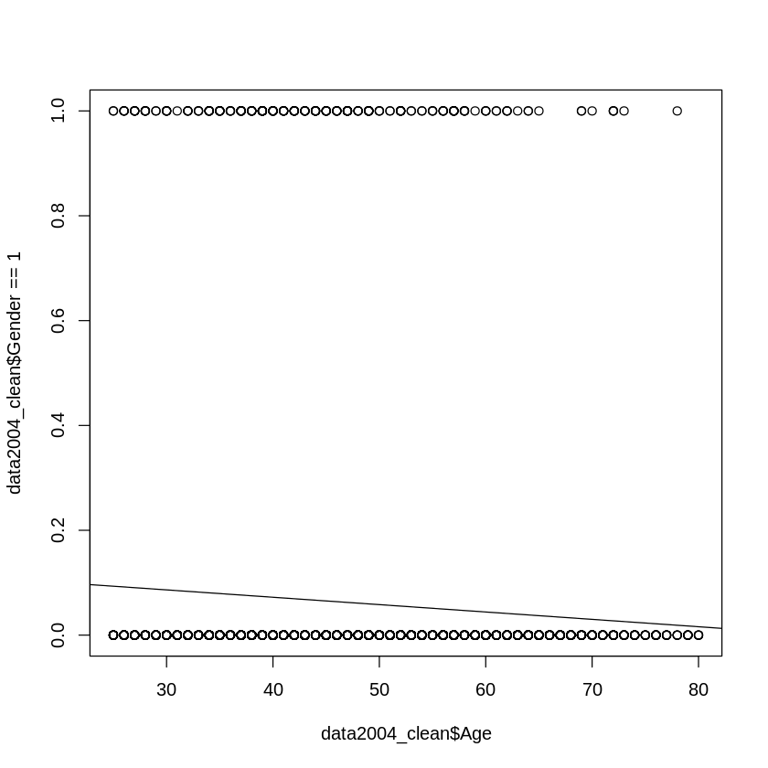

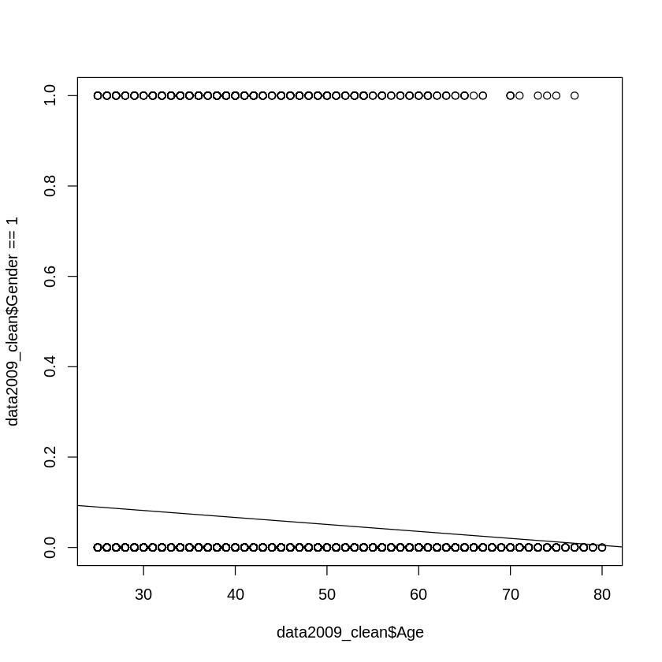

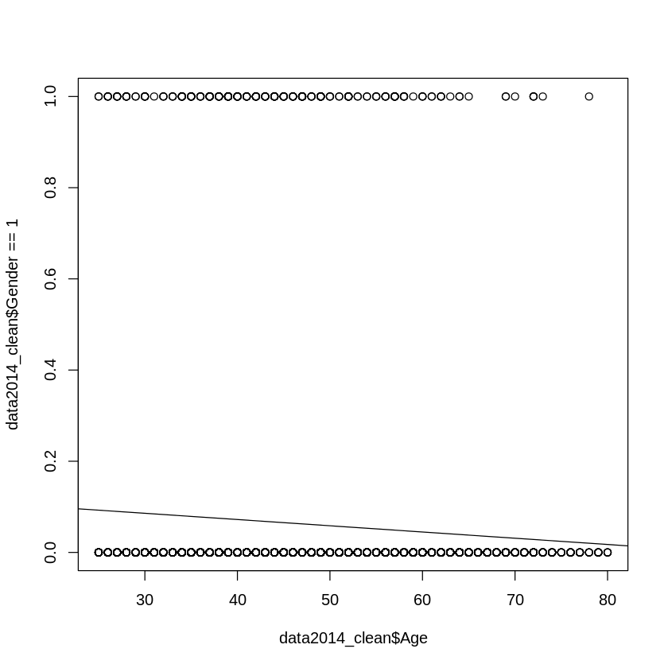

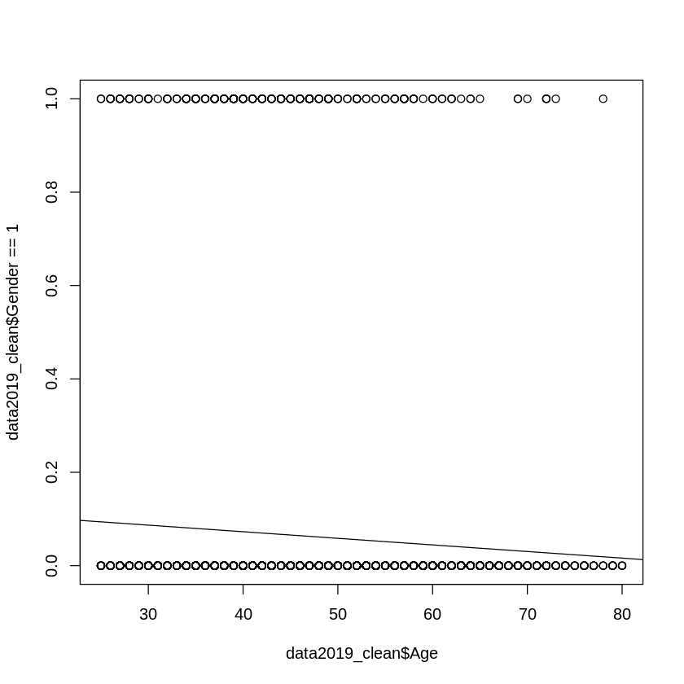

```r
plot(data2004_clean$Gender==1 ~ data2004_clean$Age )
abline(lm(data2004_clean$Gender==1~ data2004_clean$Age))
plot(data2009_clean$Gender==1 ~ data2009_clean$Age )
abline(lm(data2009_clean$Gender==1~ data2009_clean$Age))
plot(data2014_clean$Gender==1 ~ data2014_clean$Age )
abline(lm(data2014_clean$Gender==1~ data2014_clean$Age))
plot(data2019_clean$Gender==1 ~ data2019_clean$Age )
abline(lm(data2019_clean$Gender==1~ data2019_clean$Age))
```

```r
model4.1<- lm(data2004_clean$Gender==1 ~ data2004_clean$Age )
model4.1
model4.2<- lm(data2009_clean$Gender==1 ~ data2009_clean$Age )
model4.2
model4.3<- lm(data2014_clean$Gender==1 ~ data2014_clean$Age )
model4.3
model4.4<- lm(data2019_clean$Gender==1 ~ data2019_clean$Age )
model4.4
```

```
Call:
lm(formula = data2004_clean$Gender == 1 ~ data2004_clean$Age)

Coefficients:
       (Intercept)  data2004_clean$Age
          0.128404           -0.001405
```

```
Call:
lm(formula = data2009_clean$Gender == 1 ~ data2009_clean$Age)

Coefficients:
       (Intercept)  data2009_clean$Age
          0.128060           -0.001543
```

```
Call:
lm(formula = data2014_clean$Gender == 1 ~ data2014_clean$Age)

Coefficients:
       (Intercept)  data2014_clean$Age
          0.126832           -0.001368
```

```
Call:
lm(formula = data2019_clean$Gender == 1 ~ data2019_clean$Age)

Coefficients:
       (Intercept)  data2019_clean$Age
          0.129118           -0.001412
```

Here we are checking the relation between female candidates and the total equity associated with that particular candidate.

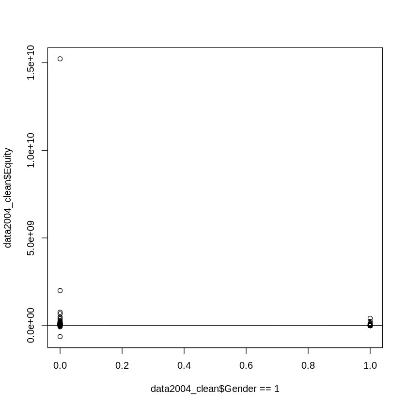

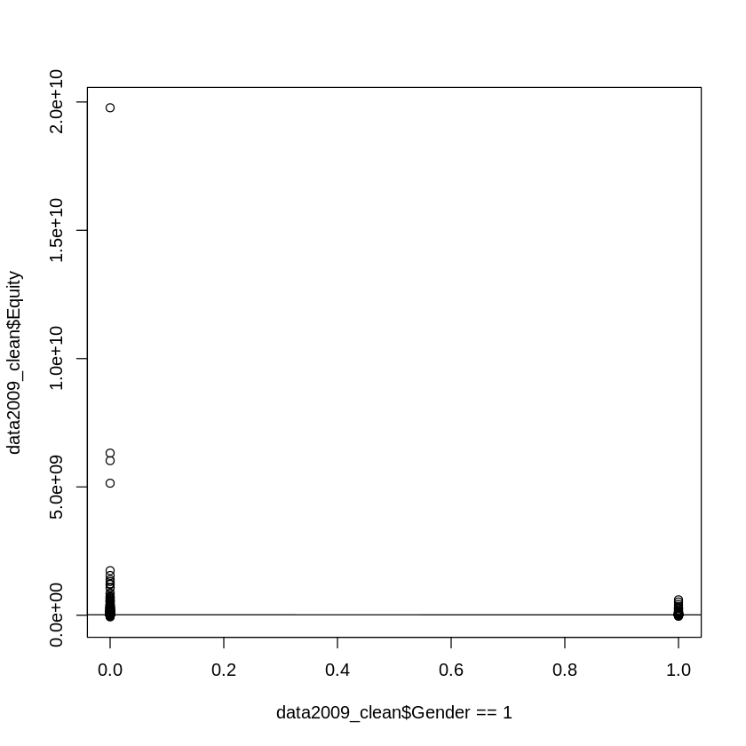

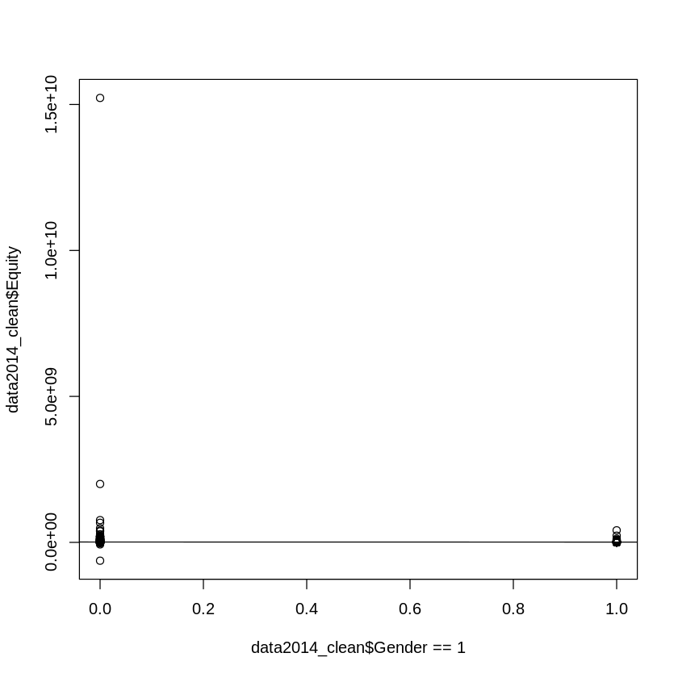

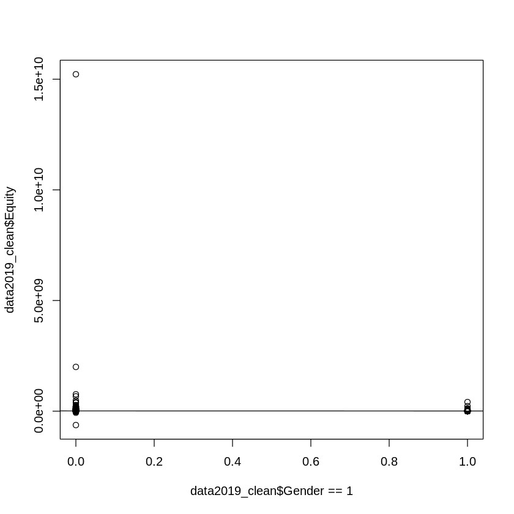

```r
plot(data2004_clean$Equity ~ data2004_clean$Gender==1 )
abline(lm(data2004_clean$Equity~ data2004_clean$Gender==1))
plot(data2009_clean$Equity ~ data2009_clean$Gender==1 )
abline(lm(data2009_clean$Equity~ data2009_clean$Gender==1))
plot(data2014_clean$Equity ~ data2014_clean$Gender==1 )
abline(lm(data2014_clean$Equity~ data2014_clean$Gender==1))
plot(data2019_clean$Equity ~ data2019_clean$Gender==1 )
abline(lm(data2019_clean$Equity~ data2019_clean$Gender==1))
```

```r
model5.1<- lm(data2004_clean$Equity ~ data2004_clean$Gender==1  )
model5.1
model5.2<- lm(data2009_clean$Equity ~ data2009_clean$Gender==1  )
model5.2
model5.3<- lm(data2014_clean$Equity ~ data2014_clean$Gender==1 )
model5.3
model5.4<- lm(data2019_clean$Equity ~ data2019_clean$Gender==1  )
model5.4
```

```
Call:
lm(formula = data2004_clean$Equity ~ data2004_clean$Gender ==
    1)

Coefficients:
                   (Intercept)  data2004_clean$Gender == 1TRUE
                      11825898                        -2563965
```

```
Call:
lm(formula = data2009_clean$Equity ~ data2009_clean$Gender ==
    1)

Coefficients:
                   (Intercept)  data2009_clean$Gender == 1TRUE
                      17891867                        -2610773
```

```
Call:
lm(formula = data2014_clean$Equity ~ data2014_clean$Gender ==
    1)

Coefficients:
                   (Intercept)  data2014_clean$Gender == 1TRUE
                      11825761                        -2489668
```

```
Call:
lm(formula = data2019_clean$Equity ~ data2019_clean$Gender ==
    1)

Coefficients:
                   (Intercept)  data2019_clean$Gender == 1TRUE
                      11813456                        -2551523
```

9) Multiple Linear Regression

Here we have the relation between candidate score and the gender of the candidate along with the Age of the candidate.

```r
model1.1 <- lm(data2004_clean$Score ~ data2004_clean$Gender + data2004_clean$Age)
model1.1
model1.2 <- lm(data2009_clean$Score ~ data2009_clean$Gender + data2009_clean$Age)
model1.2
model1.3 <- lm(data2014_clean$Score ~ data2014_clean$Gender + data2014_clean$Age)
model1.3
model1.4 <- lm(data2019_clean$Score ~ data2019_clean$Gender + data2019_clean$Age)
model1.4
```

```
Call:
lm(formula = data2004_clean$Score ~ data2004_clean$Gender + data2004_clean$Age)

Coefficients:
           (Intercept)  data2004_clean$Gender1      data2004_clean$Age
              48.33490                 1.78048                 0.03216
```

```
Call:
lm(formula = data2009_clean$Score ~ data2009_clean$Gender + data2009_clean$Age)

Coefficients:
           (Intercept)  data2009_clean$Gender1      data2009_clean$Age
              48.33658                -0.41518                 0.02249
```

```
Call:
lm(formula = data2014_clean$Score ~ data2014_clean$Gender + data2014_clean$Age)

Coefficients:
           (Intercept)  data2014_clean$Gender1      data2014_clean$Age
              48.28554                 2.51075                 0.02321
```

```
Call:
lm(formula = data2019_clean$Score ~ data2019_clean$Gender + data2019_clean$Age)

Coefficients:
           (Intercept)  data2019_clean$Gender1      data2019_clean$Age
              53.78821                -1.47960                -0.06097
```

Here we have displayed the correlation between the score of the candidate and the liabilities asscociated and the equity of the candidate.

```r
model2.1<- lm(data2004_clean$Score ~ data2004_clean$Liabilities + data2004_clean$Equity)
model2.1
model2.2<- lm(data2009_clean$Score ~ data2009_clean$Liabilities + data2009_clean$Equity)
model2.2
model2.3<- lm(data2014_clean$Score ~ data2014_clean$Liabilities + data2014_clean$Equity)
model2.3
model2.4<- lm(data2019_clean$Score ~ data2019_clean$Liabilities + data2019_clean$Equity)
model2.4
```

```
Call:
lm(formula = data2004_clean$Score ~ data2004_clean$Liabilities +
    data2004_clean$Equity)

Coefficients:
               (Intercept)  data2004_clean$Liabilities
                 5.000e+01                  -2.046e-09
     data2004_clean$Equity
                -2.731e-09
```

```
Call:
lm(formula = data2009_clean$Score ~ data2009_clean$Liabilities +
    data2009_clean$Equity)

Coefficients:
               (Intercept)  data2009_clean$Liabilities
                 4.934e+01                  -2.815e-08
     data2009_clean$Equity
                 1.662e-09
```

```
Call:
lm(formula = data2014_clean$Score ~ data2014_clean$Liabilities +
    data2014_clean$Equity)

Coefficients:
               (Intercept)  data2014_clean$Liabilities
                 4.951e+01                   5.645e-08
     data2014_clean$Equity
                -8.870e-10
```

```
Call:
lm(formula = data2019_clean$Score ~ data2019_clean$Liabilities +
    data2019_clean$Equity)

Coefficients:
               (Intercept)  data2019_clean$Liabilities
                 5.080e+01                  -6.075e-09
     data2019_clean$Equity
                 8.986e-10
```

Here we have displayed the criminal cases assosicated with the candidate and the gender along with the winning status of that candidate.

```r
model3.1<- lm(data2004_clean$Criminal.Cases ~ data2004_clean$Gender + data2004_clean$Winner)
model3.1
model3.2<- lm(data2009_clean$Criminal.Cases ~ data2009_clean$Gender + data2009_clean$Winner)
model3.2
model3.3<- lm(data2014_clean$Criminal.Cases ~ data2014_clean$Gender + data2014_clean$Winner)
model3.3
model3.4<- lm(data2019_clean$Criminal.Cases ~ data2019_clean$Gender + data2019_clean$Winner)
model3.4
```

```
Call:
lm(formula = data2004_clean$Criminal.Cases ~ data2004_clean$Gender +
    data2004_clean$Winner)

Coefficients:
           (Intercept)  data2004_clean$Gender1   data2004_clean$Winner
                0.4776                 -0.4066                 -0.4427
```

```
Call:
lm(formula = data2009_clean$Criminal.Cases ~ data2009_clean$Gender +
    data2009_clean$Winner)

Coefficients:
           (Intercept)  data2009_clean$Gender1   data2009_clean$Winner
                0.4259                 -0.3860                 -0.3776
```

```
Call:
lm(formula = data2014_clean$Criminal.Cases ~ data2014_clean$Gender +
    data2014_clean$Winner)

Coefficients:
           (Intercept)  data2014_clean$Gender1   data2014_clean$Winner
                0.4804                 -0.4084                 -0.4449
```

```
Call:
lm(formula = data2019_clean$Criminal.Cases ~ data2019_clean$Gender +
    data2019_clean$Winner)

Coefficients:
           (Intercept)  data2019_clean$Gender1   data2019_clean$Winner
                0.4789                 -0.4078                 -0.4437
```

Here we have displayed a correlation between the female candidates and the age of the candidates along with theie score for the elections.

```r
model4.1<- lm(data2004_clean$Gender==1 ~ data2004_clean$Age + data2004_clean$Score)
model4.1
model4.2<- lm(data2009_clean$Gender==1 ~ data2009_clean$Age + data2009_clean$Score)
model4.2
model4.3<- lm(data2014_clean$Gender==1 ~ data2014_clean$Age + data2014_clean$Score)
model4.3
model4.4<- lm(data2019_clean$Gender==1 ~ data2019_clean$Age + data2019_clean$Score)
model4.4
```

```
Call:
lm(formula = data2004_clean$Gender == 1 ~ data2004_clean$Age +
    data2004_clean$Score)

Coefficients:
         (Intercept)    data2004_clean$Age  data2004_clean$Score
           0.1220715            -0.0014092             0.0001304
```

```
Call:
lm(formula = data2009_clean$Gender == 1 ~ data2009_clean$Age +
    data2009_clean$Score)

Coefficients:
         (Intercept)    data2009_clean$Age  data2009_clean$Score
           1.294e-01            -1.543e-03            -2.746e-05
```

```
Call:
lm(formula = data2014_clean$Gender == 1 ~ data2014_clean$Age +
    data2014_clean$Score)

Coefficients:
         (Intercept)    data2014_clean$Age  data2014_clean$Score
           0.1177289            -0.0013716             0.0001873
```

```
Call:
lm(formula = data2019_clean$Gender == 1 ~ data2019_clean$Age +
    data2019_clean$Score)

Coefficients:
         (Intercept)    data2019_clean$Age  data2019_clean$Score
           0.1351028            -0.0014190            -0.0001117
```

```r
model5.1<- lm(data2004_clean$Equity ~ data2004_clean$Gender==1 + data2004_clean$Liabilities )
model5.1
model5.2<- lm(data2009_clean$Equity ~ data2009_clean$Gender==1 + data2009_clean$Liabilities  )
model5.2
model5.3<- lm(data2014_clean$Equity ~ data2014_clean$Gender==1 + data2014_clean$Liabilities )
model5.3
model5.4<- lm(data2019_clean$Equity ~ data2019_clean$Gender==1  + data2019_clean$Liabilities)
model5.4
```

```
Call:
lm(formula = data2004_clean$Equity ~ data2004_clean$Gender ==
    1 + data2004_clean$Liabilities)

Coefficients:
                                                (Intercept)
                                                   11842833
data2004_clean$Gender == 1 + data2004_clean$LiabilitiesTRUE
                                                   -3923751
```

```
Call:
lm(formula = data2009_clean$Equity ~ data2009_clean$Gender ==
    1 + data2009_clean$Liabilities)

Coefficients:
                                                (Intercept)
                                                   18014997
data2009_clean$Gender == 1 + data2009_clean$LiabilitiesTRUE
                                                   -6562286
```

```
Call:
lm(formula = data2014_clean$Equity ~ data2014_clean$Gender ==
    1 + data2014_clean$Liabilities)

Coefficients:
                                                (Intercept)
                                                   11845772
data2014_clean$Gender == 1 + data2014_clean$LiabilitiesTRUE
                                                   -3876530
```

```
Call:
lm(formula = data2019_clean$Equity ~ data2019_clean$Gender ==
    1 + data2019_clean$Liabilities)

Coefficients:
                                                (Intercept)
                                                   11830723
data2019_clean$Gender == 1 + data2019_clean$LiabilitiesTRUE
                                                   -3911641
```

10) Project Report

In this project we are studying about the participation of women candidates in the Indian general elections. We are looking into how females are represented in the elections and what are the factors that affect the chosen candidates.

We can clearly see that the female participation in the general elections is significantly less than the male participation. There is a need to change this dynamic.

More women should be encouraged to participate in the elections.That would raise the overall competetiveness of the election.

Workshops should be conducted to educate women on how to represent themselves in a political scenario.

Women should be introduced about concepts of negligible or no liabilities so that they dont get burdened with debt.

Exposure to political things should be provided to students from a young age. Schools can have a seperate cirriculum about general civics and politics. This can help a lot of students develop an interest in political things from a young age.

11) Originality

The source of our dataset was :

1)https://www.kaggle.com/code/paramarthasengupta/eda-plotly-prediction-indian-elections-2019

2)https://www.kaggle.com/code/themlphdstudent/2004-lok-sabha-election-eda-and-winner-prediction/notebook

The first dataset only provided us with the complete results for the Lok Sabha Election from the year 2019 and the second one has provided analysis for all 4 years with different factors such as age comparision.

We have strictly focused on Female representation in elections using the dataset which is distinct from the above adaptations and ours is not published anywhere.

For Linear regression we could not find any models using the above given datasets.